# Application areas in forensic chemistry

## Drug Identification

- Discussion of drug prohibition in Canada started in the early 1900s as a response to opium
  - HIST-3790: Opium and the making of the modern world
- Opium and Narcotics Drug Act passed in 1920; [Controlled Drugs and Substances Act (last ammended July 2026)](https://laws-lois.justice.gc.ca/eng/acts/c-38.8/)
- Resources to learn more about the [history of drug policy and other social considerations with drugs in Canada](https://drugpolicy.ca)

## Drug Identification

- Several major challenges (that can be addressed with new developments in science and technology)
  - Backlogs
    - Personnel turn around / training / lack of funding, *emerging drugs*
  - Novel Psychoactive Substances (Designer Drugs)
    - [Making $3 million dollars of fentanyl using $3,600 and a web browser](https://www.reuters.com/investigates/special-report/drugs-fentanyl-supplychain/)
    - Lack of reference data, isomers, may need new SOPs, reporting criteria, for each new drug
  - Sample complexity
    - Highly toxic drugs means that street samples actually have minor amounts of controlled material

## Drug Identification

- Some analytical solutions currently being researched include
  - Fast GC-MS; GC coupled with Cold EI-MS
  - Ambient Ionization Mass Spectrometry
  - GC-VUV / GC-IR
  - Benchtop NMR
- [Better data sharing and collaboration](https://www.nist.gov/publications/towards-increased-data-sharing-and-standardization-illicit-drug-analysis-and-monitoring) between forensic labs and cognate research areas (e.g., public health, intelligence)
- [Article: Forensic seized drug analysis: Current challenges and emerging analytical techniques](https://doi.org/10.1002%2Fwfs2.1486)

## Chemical Weapons

- The **convention on the prohibition of the development, production, stockpiling, and use of chemical weapons and of their destruction (the CWC)** was signed in 1993 and put into force in 1997
- *Chemical weapons* includes:
  - Munitions, devices, equipment specifically designed for employing munitions
  - [Toxic chemicals and their precursors](https://onlinelibrary.wiley.com/doi/book/10.1002/0470012285#page=141)
    - 57 line items: 42 individual compounds and 15 families of compounds (e.g., VX)

## Chemical Weapons

Organization for the prohibition of chemical weapons (OPCW) was established by countries to enforce the CWC

- verification studies
- retrospective and incidence response type investigations

[figure not shown]

## Fire Investigations

- Fires can be accidental or deliberate (arson). Potential motivations for deliberate fires include:
  - intent to cover up other crimes (theft, murder)
  - insurance fraud
  - civil disorder (e.g., vandalism)
  - malicious intent / terrorism
- Fire investigations begin **without certainty as to whether a crime has been committed**
  - Step 1 is to determine the merit of the assertion that the event is suspicious

## Fire Investigations

- Traditionally broken into two different stages:
  - scene investigation to determine cause, origin and development/spread of fire
  - lab analysis of samples (when arson is suspected)
- Scene investigators need to know necessary conditions for fire to be initiated and maintained, how fires develop and spread (dynamics), different types of fuel, among other investigation skills
- Lab Analysts need to have skills with analytical instrumentation and an understanding of the nature of flammable materials and their pyrolysis and combustion products to analyze fire residue/debris

## Fire Investigations

- Some relevant material properties include:
- **Flammability (explosive) limits/ranges:** outside of these limits, the fuel-vapor to air concentration will be too lean or too rich to ignite (e.g., the lower FL for 100 octane petrol is 1.4%, the upper FL is 7.6%)
- **Vapor density:** density of the fuel vapor relative to the density of air (density less than 1 will spread out at the ceiling, density greater than 1 will spread out at the floor)
- **Flash point:** lowest temperature at which a liquid fuel produces a flammable vapor
- **Flame point:** the lowest temperature at which a liquid fuel produces enough flammable vapor that it can be ignited
- **Auto-ignition temperature (AIT):** temperature at which a fuel will ignite without any additional source of ignition
- Knowing a material’s properties only helpful if you know what the material is

## Fire Investigations

- Significant research in fire investigation: [(Interpol Review)](https://www.sciencedirect.com/science/article/pii/S2589871X26000422)
- Fire scenes are hard: sample quality is poor (post fire extinguishing, a lot of components in a fuel, and weathering)
  - On-site chemical analysis
  - Models
    - Laboratory reconstructions (e.g., weathering studies)
    - Computer models

## Fire Investigations

- [The Fire Behaviour of Fabrics Containing Dried Emollient Residues](https://www.mdpi.com/2571-6255/8/4/133)
  - Proof-of-concept study
  - **Objective:** Investigate the flammability of fabrics containing dried emollient on fabrics
  - **Results:** Fabrics that have dried emollients are very flammable

## Fire Investigations

- [Artificial intelligence and thermodynamics help solving arson cases](https://www.nature.com/articles/s41598-020-77516-x)
  - Proof-of-concept study
  - **Objective:** demonstrate how combining machine learning, thermodynamic modeling and quantum mechanics can predict the composition of unweathererd gasoline samples starting from weathered ones
  - **Results:** Built and an NN model assuming an *ideal case*, where all composition change in gasoline is due exclusively to evaporation (and not adsorption, pyrolysis, degradation, extinguishing material)

## Death Investigation

- Post-mortem examinations are carried out by pathologists to try and determine cause of death
- Post-mortem examinations begin **without certainty as to whether a crime has been committed**
- Time since death is an important factor when trying to determine the cause of death
  - post-mortem interval (PMI) estimatition techniques are methods for approximating time since death

## Death Investigation

- Several established techniques for PMI estimation:
  - Pathology (looking at post-mortem changes to the body)
  - Entomology (insect activity)
- Newer techniques being researched:
  - DNA quantification (e.g., methylation)
  - Biomarker discovery
    - “OMICS” (metabolomics, lipidomics, and proteomics)
    - Looking at body (skin, hair, bones), environment (soil, water, air), microbes

## Death Investigation

- [The ‘ForensOMICS’ approach for postmortem interval estimation from human bone by integrating metabolomics, lipidomics, and proteomics](https://elifesciences.org/articles/83658)
  - Proof-of-Concept study
  - **Objective:** To evaluate the utility of combining metabolomic, lipidomic, and proteomic analysis of human bone samples to estiamte PMI–“ForensOMICS”
  - **Results:** Showed that *fingerprints* of samples collected at different time points were best separated using metabolite information; infer that “ForensOMICS” can be used to estimate PMI

## Environmental Forensic Chemistry

- A field that has developed over the past 70 years
  - A successor to drinking water quality studies
- Involves scientific investigation to:
  - Decipher the source(s) and fate(s) of environmental contaminants
  - Identify culprit
- Enforcement and protections of acts and regulations: [Environment and Climate Change Canada Acts & Regulations](https://www.canada.ca/en/environment-climate-change/corporate/transparency.html)

## Environmental Forensic Chemistry

- Environmental Protection Acts
  - The Department of the Environment Act
  - The Canada Water Act
  - International Rivers Improvement Act (IRIA)
  - Lake of the Woods Control Board Act
  - Weather Modification Act
- Pollution Prevention Acts
  - Canadian Environmental Protections Act
  - Fisheries Act
  - Antarctic Environmental Protections Act
  - Artic Waters Pollution Prevention Act

## Environmental Forensic Chemistry

- Biodiversity and Conservation
  - Species at Risk Act
  - Migratory Birds Convention Act
  - Wild Animals and Plant Protection and Regulation of International and Interprovincial Trade Act
  - Canada Wildlife Act
- Sustainable Development
  - Federal Sustainable Development Act
  - Canada Foundation of Sustainable Development Technology Act

## Environmental Forensic Chemistry

- The credibility of environmental forensic chemistry results is directly related to the quality of measurements and interpretations
- Some well-known challenges in measurement quality include:
  - Sensitivity / Specificity
  - Changing targets (laws and regulations)
  - *Sampling (environmental systems are complex)*

## Environmental Forensic Chemistry

- **Case Study:** Characterizing Per- and Polyfluoroalkyl substances (PFAS)
- **PFAS:** group of thousands of synthetic chemicals that are used in consumer products and industrial processes
  - Non-stick cookware, cosmetics, cleaning products, food packaging
  - firefighting foam, *lab equipment*
- Discovered in the 1930s; commonly used since the 1950s; started noticing environmental persistence and health effects in humans in the 1970s; subject of *some* environmental protection since 2000s

## Environmental Forensic Chemistry

- Known health effects in animals:
  - liver damage, immune system malfunction, reproductive and developmental issues, tumors
- Suspected health effects (correlations) in humans:
  - liver damage, increased serum cholesterol, decreased vaccination response, decreased birth weight, increased chance of thyroid disease, cardiovascular issues, cancer
- Several governing bodies have created standards for allowable levels of specific PFAS in consumer products and the environment

## Environmental Forensic Chemistry

- [Source attribution of Poly- and Perfluoralkyl Substances (PFASs) in surface waters from Rhode Island and New York Metropolitan Area](https://doi.org/10.1021/acs.estlett.6b00255)
- **Objective:** Identify sources of surface water PFAS contamination in a specified geography
- **Methods (summary):**
  - sampled water at 28 sites in Rhode Island and 9 sites in NY/NJ
  - samples were spiked with known amount of PFAS
  - PFAS were then extracted and then analyzed using LC/MS-MS
  - Statistical and spatial analysis

## White collar crimes - Illegal Timber trade

Illegal logging is one of the [most profitable natural resource crimes](https://gfintegrity.org/report/transnational-crime-and-the-developing-world/)

- Species Identification / Origin Identification

| Transnational Crime | Estimated Annual Value (USD) |
| --- | --- |
| Counterfeiting | 923 billion to 1.13 trillion |
| Drug Trafficking | 426 billion to 652 billion |
| **Illegal Logging** | **52 billion to 157 billion** |
| Human Trafficking | 150.2 billion |
| Illegal Mining | 12 billion to 48 billion |
| Illegal Fishing | 15.5 billion to 36.4 billion |
| Illegal Wildlife Trade | 5 billion to 23 billion |
| Crude Oil Theft | 5.2 billion to 11.9 billion |
| Small Arms and Light Weapons Trafficking | 1.7 billion to 3.5 billion |
| Organ Trafficking | 840 million to 1.7 billion |
| Tracking in Cultural Property | 1.2 billion to 1.6 billion |
| Total | 1.6 trillion to 2.2 trillion |

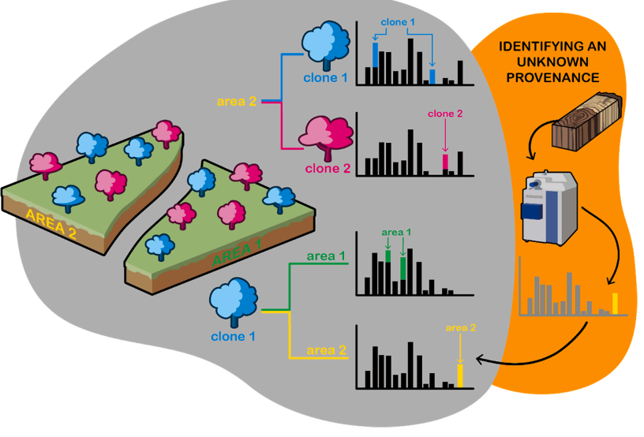

Illustration of Chemotype from [Deklerk (2023).](https://doi.org/10.1016/j.fsiae.2022.100057)

## Coming up

- Seminars are running in-person on Thursday October 8th
  - F01 (SC 204) and F02 (SC W1))
- **Lecture next week:** An introduction to (or refresher on) programming in R